# Differential expression for sleep deprivation RNA-seq.

Jakub Orzechowski Westholm

```r
cat(paste(Sys.Date()))
```

```
## 2018-05-30
```

This document contains the RNA-seq analysis for the study by Cedernaes et al. 2018.

### Load libraries

```r
library(knitr)
library(edgeR)
library(biomaRt)
library(tidyverse)
library(gage)
library(gageData)
library(pathview)
library(VennDiagram)
library(pheatmap)
```

### Helper functions

```r
# Run differential expression analysis with EdgeR.
# Inputs:
# - a count table (rows are genes, columns are samples)
# - which model to use (a string representing a formula)
# - a table with phenotype data (rows are samples, columns are phenotypes etc.)
# - minimum threshold of counts per million (CPM) for filtering genes (default=1)
# - minimum number of samples a gene has to have CPM above the given threshold (default=5)
# - if coeficiant of variation should be plotted (default=TRUE)
# - the highest p-value to include in the output (default=1, include all genes)
# - an array mapping ENSG ids to gene names
# - an array mapping ENSG ids to Entrez ids
# Output:
# - A table of differential expression results, with the following columns:
# "logFC", "logCPM", "LR", "PValue", "FDR", "gene_names", "entrez"
run.edger.analys <- function(use.counts, use.model, sample.tab, min.cpm=1, min.samples=5,
                                                         plot.bcv=TRUE, max.pval=1, genenames=NULL, entrez=NULL){

    y <- DGEList(counts=use.counts)

    keep <- rowSums(cpm(y)>min.cpm) >= min.samples
    y <- y[keep, keep.lib.sizes=FALSE]

    use.sample.tab <- sample.tab[colnames(use.counts),]

    design <- model.matrix(as.formula(use.model), data=use.sample.tab )

    ## Normalize
    y <- calcNormFactors(y)

    ## Estimating disperions
    y <- estimateGLMCommonDisp(y,design)
    y <- estimateGLMTrendedDisp(y,design)
    y <- estimateGLMTagwiseDisp(y,design)

    if(plot.bcv){
        plotBCV(y)
    }

    ## Testing for differential expression
    fit <- glmFit(y, design)
    lrt <- glmLRT(fit)

    out.tab <- topTags(lrt, n=1000000, p.value=max.pval)$table

    ## Add gene info
    if(!is.null(genenames)){
        out.tab <- cbind(out.tab, gene_names=genenames[rownames(out.tab)])
    }
    if(!is.null(entrez)){
        out.tab <- cbind(out.tab, entrez=entrez[rownames(out.tab)])
    }
    return(out.tab)
}



# Volcano plot: log fold change on x-axis and -log (pval) on y-axis.
# Input:
# - Table with differential expression (with log fold change on col 1 and p-val in col 5)
# - p-value threshold
# - fold change threshold
# - Title
# Plots a volcano plot. Genes above the thresholds are highlighted with different colors.
volcano.plot <- function(top.tab, pval.cutoff=0.05, fc.cutoff=1, main=""){
    res <- cbind(top.tab[,1],-log10(top.tab[,5]))
    rownames(res) <- rownames(top.tab)
    colnames(res) <- c("logFC", ylab="-log10(P)")

    plot(res, pch=20, cex=0.5, xlab="logFC", ylab="-log10 P",main=main)

    # Add colored points: red if padj<0.05, orange of log2FC>1, green if both)
    points(subset(res, res[,2] > -1* log10(pval.cutoff) ), pch=20, cex=0.5, col="red")
    points(subset(res, abs(res[,1]) > fc.cutoff), pch=20, cex=0.5, col="green")
}


# Run GAGE pathway anslysis.
# Input:
# - Table with differential expression, with the following columns:
#   "logFC", "logCPM", "LR", "PValue", "FDR", "gene_names", "entrez"
# - List of gene sets, mapping gene set name to Entrez gene ids.
# - Wich measure to use, "logFC" or "logP" ( -1*log(P)*sign(logFC) )
# Output is a list with 3 elements ("greater", "less", "stats"), output by gage.
# See ?gage for more info.
run.gage <- function(top.tab, gene.sets, measure="logFC"){
    use.genes <- !is.na(top.tab$entrez)

    use.measure <- NULL
    if(measure=="logFC"){
        use.measure <- top.tab$logFC[use.genes]
    }
    if(measure=="logP"){
        use.measure <- sign(top.tab$logFC[use.genes])*-1*log10(top.tab$PValue[use.genes])
    }
    names(use.measure) <- top.tab$entrez[use.genes]
    return( gage(use.measure, gsets = gene.sets, ref = NULL, samp = NULL, use.fold = TRUE, saaTest = gs.KSTest, rank.test = TRUE) )
}


# Print top gene sets from GAGE analysis.
# Input:
# - output from GAGE
# - threshold on the q-value (default=0.01)
# - direction of change ("up" or "down")
top.gage.sets <- function(gage.data, qval.threshold=0.05, change){
    use.cols <- c(2,4,5)
        tmp.data <- NULL
    if(change=="up"){
        tmp.data <- gage.data[[1]]
    }
    else if(change=="down"){
        tmp.data <- gage.data[[2]]
    }else{
        stop(paste("Error in top.gage.sets! Expected change=\"up\" or \"down\", got", change))
    }

    # Format output, round numbers and truncate long strings.
    out.tab <- tmp.data[which(tmp.data[,"q.val"] < qval.threshold), use.cols ]

    if(!is.null(dim(out.tab))){
            if(nrow(out.tab) == 0){
                return(out.tab)
            }
    }
    if(is.null(dim(out.tab))){ # ugly hack to catch error if there's only one gene set.
        out.tab <- as.data.frame(t(out.tab))
        rownames(out.tab) <- rownames(tmp.data)[which(tmp.data[,"q.val"] < qval.threshold)]
    }


    rownames(out.tab) <- strtrim(rownames(out.tab), 50)
    out.tab[,"stat.mean"] <- round(out.tab[,"stat.mean"], 2)
    out.tab[,"q.val"] <- signif(out.tab[,"q.val"], 2)
    return( out.tab )
}


## Compared differentially expressed genes in two tissues, and plot a Venn diagram. Input:
## - EdgeR output for tissue 1 (adipose)
## - EdgeR output for tissue 2 (muscle)
## Output:
## - Venn diagram with overlaps between up- and down.regulated genes in the two tissues.
compare.tissues.venn <- function(edger.a, edger.m, max.pval){
    a.up.genes <- rownames(edger.a[which(edger.a$FDR < max.pval & edger.a$logFC > 0),])
    a.down.genes <- rownames(edger.a[which(edger.a$FDR < max.pval & edger.a$logFC < 0),])

    m.up.genes <- rownames(edger.m[which(edger.m$FDR < max.pval & edger.m$logFC > 0),])
    m.down.genes <- rownames(edger.m[which(edger.m$FDR < max.pval & edger.m$logFC < 0),])

    draw.quad.venn(
        area1 = length(a.up.genes),
        area2 = length(a.down.genes),
        area3 = length(m.up.genes),
        area4 = length(m.down.genes),
        n12 = 0,
        n13 = length(intersect(a.up.genes, m.up.genes)),
        n14 = length(intersect(a.up.genes, m.down.genes)),
        n23 = length(intersect(a.down.genes, m.up.genes)),
        n24 = length(intersect(a.down.genes, m.down.genes)),
        n34 = 0,
        n123 = 0,
        n124 = 0,
        n134 = 0,
        n234 = 0,
        n1234 = 0,
        category = c("Adipose Up", "Adipose Down", "Muscle Up", "Muscle down"),
        fill = c("orange", "red", "green", "blue"),
        lty = "blank",
        cex = 1.4,
        cat.cex = 1.3,
        cat.col = rep("black", 4)
    )
}
```

### Load and organize data

```r
## read gene counts
gene.count.file <- "all_counts.txt"
count.tab <- read.table(gene.count.file, sep="\t", header=TRUE)
colnames(count.tab) <- gsub("^X", "", colnames(count.tab), perl=TRUE) # Clean up column names in count table

## Read sample sheet
sample.file <- "rna_seq_data_table.csv"
sample.tab <- read.csv(sample.file, as.is = TRUE)
rownames(sample.tab) <- gsub("\"", "", apply(sample.tab[,3:1], 1, function(x){paste(x,collapse = ".")})) # Clean up row names in sample sheet
head(sample.tab)
```

```
##          Tissue Sleep Subject_ID Age_at_time_of_first_session   BMI
## 01.SMW.A      A   SMW       "01"                           23 22.86
## 02.SMW.A      A   SMW       "02"                           23 20.91
## 03.SMW.A      A   SMW       "03"                           25 21.91
## 04.SMW.A      A   SMW       "04"                           19 20.71
## 05.SMW.A      A   SMW       "05"                           21 20.32
## 06.SMW.A      A   SMW       "06"                           23 24.27
##          Waist_circumference_cm Hip_circumference_cm Waist.hip_ratio
## 01.SMW.A                   83.5                100.0           0.835
## 02.SMW.A                   93.0                 99.5           0.935
## 03.SMW.A                   78.5                 97.5           0.805
## 04.SMW.A                   77.0                 98.0           0.786
## 05.SMW.A                   76.0                 94.0           0.809
## 06.SMW.A                   94.0                104.0           0.904
##          Pre_SMS_Diary_Sleep_duration_per_night
## 01.SMW.A                                 507.85
## 02.SMW.A                                 492.15
## 03.SMW.A                                 467.15
## 04.SMW.A                                 548.57
## 05.SMW.A                                 460.57
## 06.SMW.A                                 565.72
##          Pre_SMW_Diary_Sleep_duration_per_night MEQ_data
## 01.SMW.A                                 473.57       61
## 02.SMW.A                                 513.57       37
## 03.SMW.A                                 451.43       48
## 04.SMW.A                                 568.57       42
## 05.SMW.A                                 454.72       49
## 06.SMW.A                                 504.28       58
##          First_session_date Second_session_date
## 01.SMW.A         2013-06-14          2013-07-19
## 02.SMW.A         2013-03-25          2013-05-08
## 03.SMW.A         2013-03-18          2013-06-04
## 04.SMW.A         2013-03-29          2013-06-04
## 05.SMW.A         2013-03-29          2013-05-24
## 06.SMW.A         2013-03-25          2013-05-08
##          First_session_sleep_condition
## 01.SMW.A                           SMS
## 02.SMW.A                           SMW
## 03.SMW.A                           SMS
## 04.SMW.A                           SMS
## 05.SMW.A                           SMS
## 06.SMW.A                           SMW
```

```r
## Fetch gene info. Run this once. Then just reload saved object.
ensembl = useEnsembl(biomart="ensembl",GRCh=37, dataset="hsapiens_gene_ensembl")
gene.annot.tab <- getBM(attributes=c('ensembl_gene_id','gene_biotype','entrezgene', 'external_gene_name'), mart = ensembl)

## Clean up data: if there are several entries with same ensembl_gene_id, use the first
gene.annot.tab %>%
    group_by(ensembl_gene_id) %>%
    summarise_each(funs(paste(sort(.), collapse=","))) %>%
    extract(external_gene_name, "external_gene_name", "([^,]+),?.*") %>%
    extract(gene_biotype, "gene_biotype", "([^,]+),?.*") %>%
    extract(entrezgene, "entrezgene", "([^,]+),?.*") -> gene.annot.tab
```

```
## `summarise_each()` is deprecated.
## Use `summarise_all()`, `summarise_at()` or `summarise_if()` instead.
## To map `funs` over all variables, use `summarise_all()`
```

```r
head(gene.annot.tab)
```

```
## # A tibble: 6 x 4
##   ensembl_gene_id gene_biotype   entrezgene external_gene_name
##   <chr>           <chr>          <chr>      <chr>
## 1 ENSG00000000003 protein_coding 7105       TSPAN6
## 2 ENSG00000000005 protein_coding 64102      TNMD
## 3 ENSG00000000419 protein_coding 8813       DPM1
## 4 ENSG00000000457 protein_coding 57147      SCYL3
## 5 ENSG00000000460 protein_coding 55732      C1orf112
## 6 ENSG00000000938 protein_coding 2268       FGR
```

```r
biotypes <- gene.annot.tab$gene_biotype
names(biotypes) <- gene.annot.tab$ensembl_gene_id

genenames <- gene.annot.tab$external_gene_name
names(genenames) <- gene.annot.tab$ensembl_gene_id

entrez <- gene.annot.tab$entrezgene
names(entrez) <- gene.annot.tab$ensembl_gene_id

protein.coding.genes <- names(biotypes)[biotypes == "protein_coding"]
```

Select gene expression data to look at

```r
gene.filter <- protein.coding.genes
count.filtered <- count.tab[intersect(rownames(count.tab),gene.filter),]

count.filtered.a <- count.filtered[, grep(".A", colnames(count.filtered), fixed = TRUE)]
count.filtered.m <- count.filtered[, grep(".M", colnames(count.filtered), fixed = TRUE)]
```

# Differential expression with EdgeR

```r
use.model <- "~Subject_ID + Sleep"

min.cpm <- 1
min.samples <- 5
edger.a <- run.edger.analys(count.filtered.a, use.model, sample.tab, min.cpm=min.cpm, min.samples=min.samples, genenames=genenames, entrez=entrez)
```

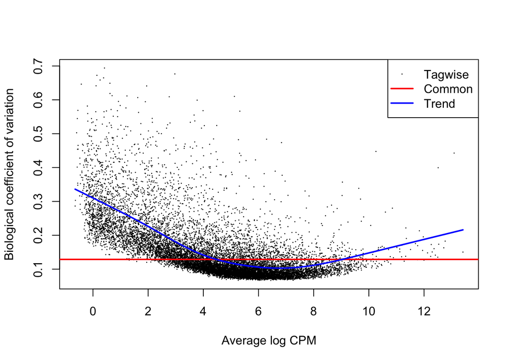

```r
edger.m <- run.edger.analys(count.filtered.m, use.model, sample.tab, min.cpm=min.cpm, min.samples=min.samples, genenames=genenames, entrez=entrez)
```

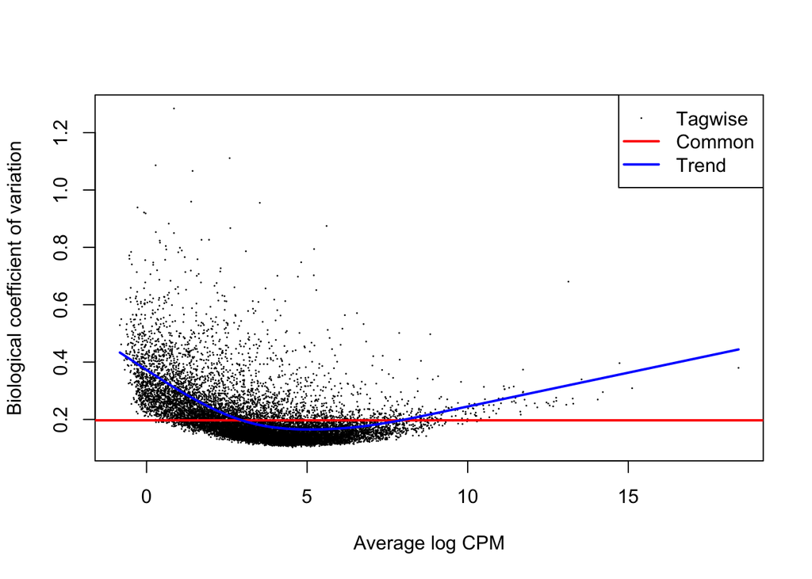

```r
head(edger.a)
```

```
##                      logFC   logCPM       LR       PValue          FDR
## ENSG00000043591  0.9139334 3.847249 37.55281 8.897093e-10 1.253778e-05
## ENSG00000154359 -0.4643168 6.694324 34.39745 4.493114e-09 3.165848e-05
## ENSG00000175084 -1.6058093 2.077009 28.92735 7.514449e-08 3.529787e-04
## ENSG00000168237  0.3592772 4.921039 27.53337 1.544071e-07 5.439763e-04
## ENSG00000113742 -0.2485915 6.868250 25.76288 3.860422e-07 9.965437e-04
## ENSG00000164674  0.3925697 4.130782 24.86126 6.160823e-07 9.965437e-04
##                 gene_names entrez
## ENSG00000043591      ADRB1    153
## ENSG00000154359     LONRF1  91694
## ENSG00000175084        DES   1674
## ENSG00000168237     GLYCTK 132158
## ENSG00000113742      CPEB4  80315
## ENSG00000164674      SYTL3  94120
```

Number of differentially expressed genes

```r
max.pval <- 0.05
length(which(edger.a$FDR < max.pval))
```

```
## [1] 97
```

```r
length(which(edger.m$FDR < max.pval))
```

```
## [1] 118
```

Write lists of differentially expressed genes to text files.

```r
write.table(edger.a[edger.a$FDR < 0.05 & edger.a$logFC > 0,], file="adipose_up.txt", row.names = T, col.names = T, quote = F)
write.table(edger.a[edger.a$FDR < 0.05 & edger.a$logFC < 0,], file="adipose_down.txt", row.names = T, col.names = T, quote = F)

write.table(edger.m[edger.m$FDR < 0.05 & edger.m$logFC > 0,], file="muscle_up.txt", row.names = T, col.names = T, quote = F)
write.table(edger.m[edger.m$FDR < 0.05 & edger.m$logFC < 0,], file="muscle_down.txt", row.names = T, col.names = T, quote = F)
```

# Overlaps between differentially regulated genes from adipse and muscle

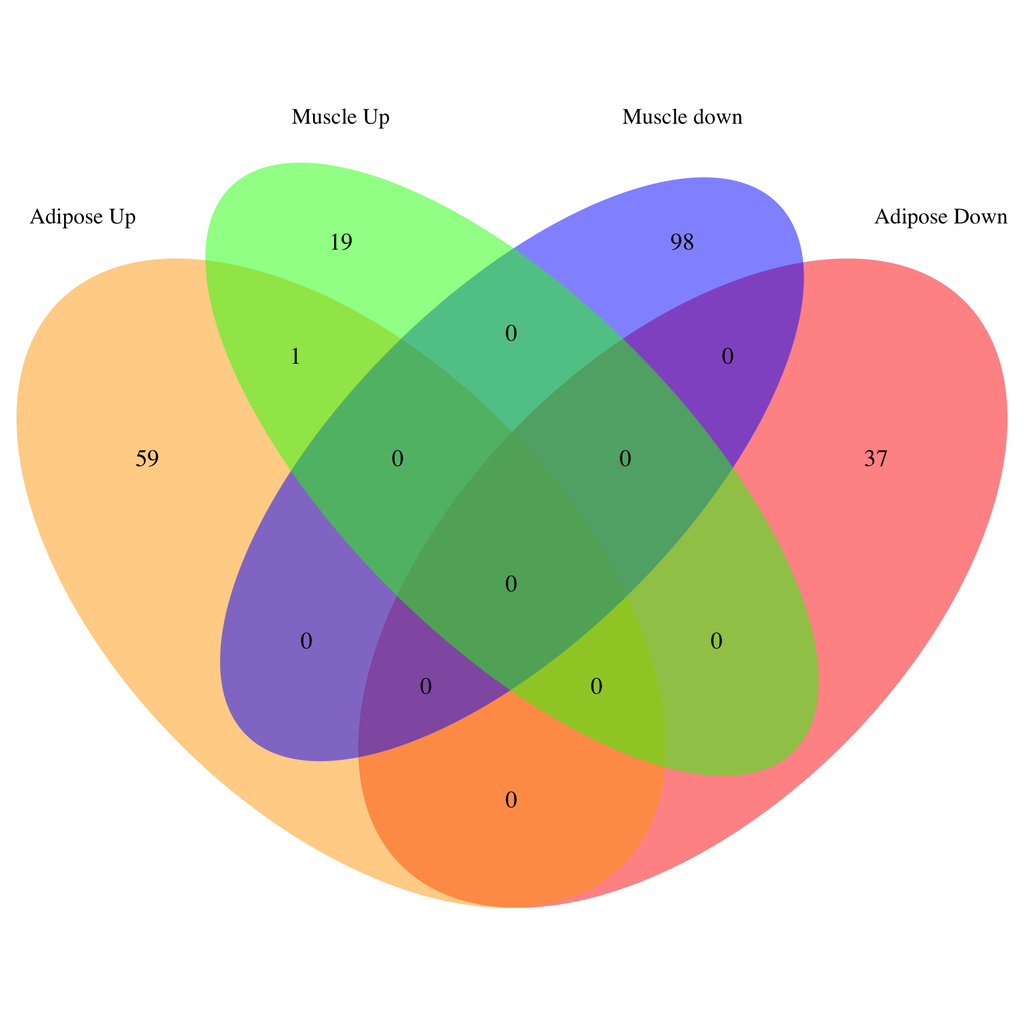

```r
compare.tissues.venn(edger.a, edger.m, max.pval)
```

## Volcano plots

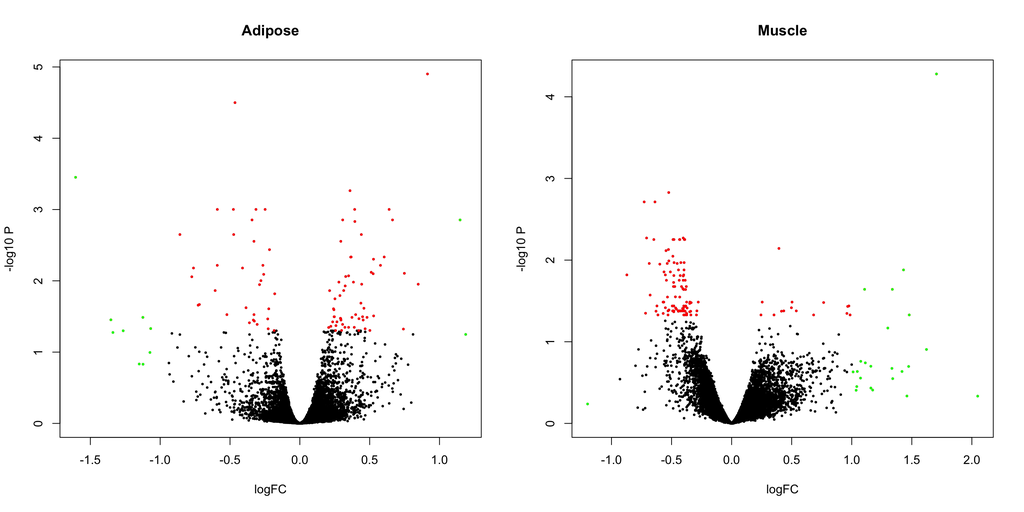

```r
par(mfrow=c(1,2))
volcano.plot(edger.a, pval.cutoff=0.05, fc.cutoff=1, main="Adipose")
volcano.plot(edger.m, pval.cutoff=0.05, fc.cutoff=1, main="Muscle")
```

## Heatmaps of differentially expressed genes

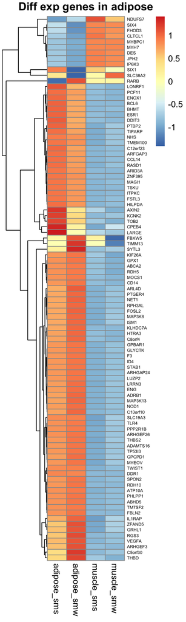

```r
scale_rows = function(x){
    m = apply(x, 1, mean, na.rm = T)
    s = apply(x, 1, sd, na.rm = T)
    return((x - m) / s)
}

## Calculate log CPM (counts per million mapped reads)
logcpm.a <- cpm(DGEList(count.filtered.a), prior.count=2, log=TRUE)
logcpm.m <- cpm(DGEList(count.filtered.m), prior.count=2, log=TRUE)
rownames(logcpm.a) <- genenames[rownames(logcpm.a)]
rownames(logcpm.m) <- genenames[rownames(logcpm.m)]

## Reorder columns, and rescale (to mean=0 and sd=1)
plot.data.a <- logcpm.a[,c(seq(from=1, to=30,by=2), seq(from=2, to=30, by=2))]
plot.data.m <- logcpm.m[,c(seq(from=1, to=30,by=2), seq(from=2, to=30, by=2))]
plot.data.am <- cbind(scale_rows(plot.data.a), scale_rows(plot.data.m))


pval.cutoff = 0.05
use.genes.a <- genenames[rownames(edger.a)[edger.a$FDR<pval.cutoff]]
use.genes.m <- genenames[rownames(edger.m)[edger.m$FDR<pval.cutoff]]
use.genes.am <- union(use.genes.a, use.genes.m)
names(use.genes.am) <- use.genes.am


## Plot (rescaled) expression levels
de.exp <- cbind(adipose_sms=apply(plot.data.a[use.genes.am,1:15],1,mean),
                                adipose_smw=apply(plot.data.a[use.genes.am,16:30],1,mean),
                                muscle_sms=apply(plot.data.m[use.genes.am,1:15],1,mean),
                                muscle_smw=apply(plot.data.m[use.genes.am,16:30],1,mean))
pheatmap(de.exp[use.genes.a,], cluster_rows=TRUE, cluster_cols=FALSE, scale="row",
                 annotation_col=NULL, main="Diff exp genes in adipose", fontsize_row=5)
```

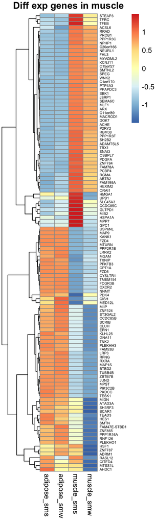

```r
pheatmap(de.exp[use.genes.m,], cluster_rows=TRUE, cluster_cols=FALSE, scale="row",
                 annotation_col=NULL, main="Diff exp genes in muscle", fontsize_row=5)
```

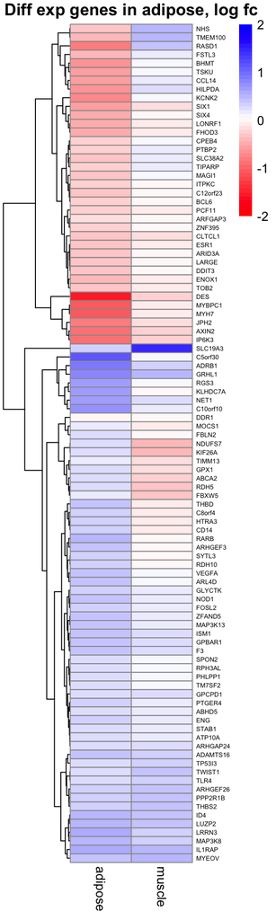

```r
## Plot log fold changes
de.diff.exp.a <- do.call("cbind", lapply(seq(from=1, to=30, by=2), function(i){ logcpm.a[use.genes.am ,i+1] - logcpm.a[use.genes.am ,i] }))
de.diff.exp.m <- do.call("cbind", lapply(seq(from=1, to=30, by=2), function(i){ logcpm.m[use.genes.am ,i+1] - logcpm.m[use.genes.am, i] }))
de.diff.exp <- cbind(adipose=apply(de.diff.exp.a,1,mean),
                                         muscle=apply(de.diff.exp.m,1,mean))
de.diff.exp <- de.diff.exp[order(apply(de.diff.exp,1,mean)),] ## Order on average fc


paletteLength <- 50
myColor <- colorRampPalette(c("red", "white", "blue"))(paletteLength)
max.fc <- ceiling(max(abs(de.diff.exp)))
pheatmap(de.diff.exp[use.genes.a,], cluster_rows=TRUE, cluster_cols=FALSE, scale="none", annotation_col=NULL, main="Diff exp genes in adipose, log fc", fontsize_row=5, color = myColor, breaks = seq(from=-1*max.fc, to=max.fc, length.out=paletteLength))
```

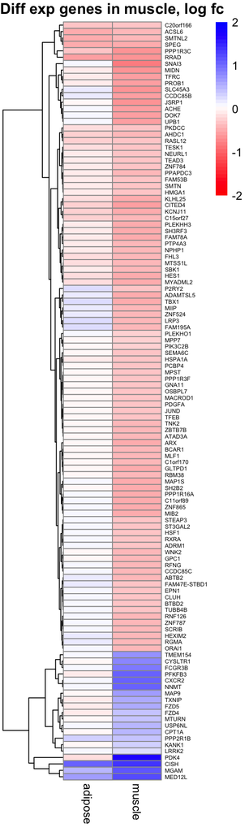

```r
pheatmap(de.diff.exp[use.genes.m,], cluster_rows=TRUE, cluster_cols=FALSE, scale="none", annotation_col=NULL,
                 main="Diff exp genes in muscle, log fc", fontsize_row=5, color = myColor, breaks = seq(from=-1*max.fc, to=max.fc, length.out=paletteLength))
```

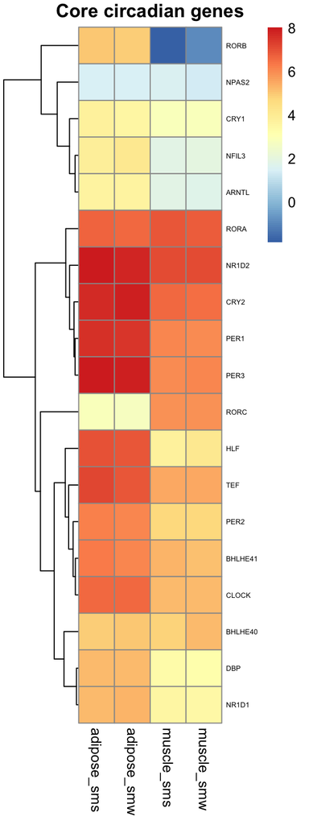

```r
## Plot core circadian genes

core.circadian.genes <- c("TEF", "CRY2", "HLF", "BHLHE41", "CRY1", "RORB", "CLOCK", "PER2", "PER1", "NFIL3", "DBP", "NR1D2", "NR1D1", "NPAS2", "RORC", "PER3", "RORA", "BHLHE40", "ARNTL")
names(core.circadian.genes) <- c("ENSG00000167074", "ENSG00000121671", "ENSG00000108924", "ENSG00000123095", "ENSG00000008405", "ENSG00000198963", "ENSG00000134852", "ENSG00000132326", "ENSG00000179094", "ENSG00000165030", "ENSG00000105516", "ENSG00000174738", "ENSG00000126368", "ENSG00000170485", "ENSG00000143365", "ENSG00000049246", "ENSG00000069667", "ENSG00000134107", "ENSG00000133794")

core.circ.exp <- cbind(adipose_sms=apply(plot.data.a[core.circadian.genes,1:15],1,mean),
                                             adipose_smw=apply(plot.data.a[core.circadian.genes,16:30],1,mean),
                                             muscle_sms=apply(plot.data.m[core.circadian.genes,1:15],1,mean),
                                             muscle_smw=apply(plot.data.m[core.circadian.genes,16:30],1,mean))
pheatmap(core.circ.exp, cluster_rows=TRUE, cluster_cols=FALSE, scale="none",
                 annotation_col=NULL, main="Core circadian genes", fontsize_row=5)
```

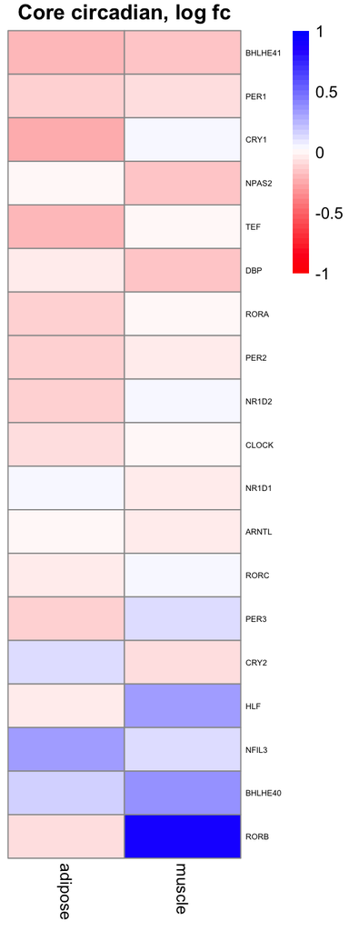

```r
core.circ.diff.exp.a <- do.call("cbind", lapply(seq(from=1, to=30, by=2), function(i){ logcpm.a[core.circadian.genes,i+1] -  logcpm.a[core.circadian.genes,i] }))
core.circ.diff.exp.m <- do.call("cbind", lapply(seq(from=1, to=30, by=2), function(i){ logcpm.m[core.circadian.genes,i+1] - logcpm.m[core.circadian.genes,i] }))
core.circ.diff.exp <- cbind(adipose=apply(core.circ.diff.exp.a,1,mean),
                                                        muscle=apply(core.circ.diff.exp.m,1,mean))
core.circ.diff.exp <- core.circ.diff.exp[order(apply(core.circ.diff.exp,1,mean)),] ## Order on average fc

paletteLength <- 50
myColor <- colorRampPalette(c("red", "white", "blue"))(paletteLength)
max.fc <- ceiling(max(abs(core.circ.diff.exp)))
pheatmap(core.circ.diff.exp, cluster_rows=FALSE, cluster_cols=FALSE, scale="none",
                 annotation_col=NULL, main="Core circadian, log fc", fontsize_row=5,
                 color = myColor,
                 breaks = seq(from=-1*max.fc, to=max.fc, length.out=paletteLength))
```

# Pathway analysis

Here we combine the information from individual genes, to see if any groups of genes (representing pathways, complexes, biological finctions etc.) show differential expression. We try two different approaches:

## Enrichr

Enrichr ia a web tool where you can upload lists of genes, and look for overlaps with gene sets from many different sources (Gene Ontology, KEGG, Wikipathays, ENCODE, GTEx). The tool can be found at http://amp.pharm.mssm.edu/Enrichr/. The following code generates gene lists that can be pasted into the web form.

```r
a.up.genes <- edger.a$gene_names[edger.a$FDR < 0.05 & edger.a$logFC > 0]
a.down.genes <- edger.a$gene_names[edger.a$FDR < 0.05 & edger.a$logFC < 0]

m.up.genes <- edger.m$gene_names[edger.m$FDR < 0.05 & edger.m$logFC > 0]
m.down.genes <- edger.m$gene_names[edger.m$FDR < 0.05 & edger.m$logFC < 0]

write.table(a.up.genes, row.names = F, col.names = F, quote = F) ## up DE genes from adipose
```

```
## ADRB1
## GLYCTK
## SYTL3
## NET1
## ATP10A
## RGS3
## C5orf30
## NOD1
## VEGFA
## ARHGAP24
## PPP2R1B
## IL1RAP
## SLC19A3
## ID4
## LRRN3
## MAP3K8
## C10orf10
## LUZP2
## HTRA3
## PTGER4
## RPH3AL
## FOSL2
## ZFAND5
## GRHL1
## THBS2
## ENG
## MOCS1
## NDUFS7
## PHLPP1
## ADAMTS16
## MAP3K13
## TWIST1
## TLR4
## DDR1
## RARB
## GPCPD1
## ISM1
## ABCA2
## ARHGEF26
## ARL4D
## SPON2
## THBD
## STAB1
## KIF26A
## ARHGEF3
## TM7SF2
## FBLN2
## TP53I3
## RDH5
## FBXW5
## C8orf4
## RDH10
## CD14
## TIMM13
## GPBAR1
## KLHDC7A
## ABHD5
## MYEOV
## GPX1
## F3
```

```r
write.table(a.down.genes, row.names = F, col.names = F, quote = F) ## down DE genes from adipose
```

```
## LONRF1
## DES
## CPEB4
## SIX1
## SIX4
## MAGI1
## NHS
## AXIN2
## FHOD3
## LARGE
## PCF11
## C12orf23
## CCL14
## FSTL3
## RASD1
## BCL6
## JPH2
## CLTCL1
## SLC38A2
## HILPDA
## ARFGAP3
## BHMT
## KCNK2
## ENOX1
## PTBP2
## ESR1
## TSKU
## MYBPC1
## TIPARP
## IP6K3
## DDIT3
## TOB2
## TMEM100
## ARID3A
## MYH7
## ITPKC
## ZNF395
```

```r
write.table(union(a.down.genes, a.up.genes), row.names = F, col.names = F, quote = F) ## all DE genes from adipose
```

```
## LONRF1
## DES
## CPEB4
## SIX1
## SIX4
## MAGI1
## NHS
## AXIN2
## FHOD3
## LARGE
## PCF11
## C12orf23
## CCL14
## FSTL3
## RASD1
## BCL6
## JPH2
## CLTCL1
## SLC38A2
## HILPDA
## ARFGAP3
## BHMT
## KCNK2
## ENOX1
## PTBP2
## ESR1
## TSKU
## MYBPC1
## TIPARP
## IP6K3
## DDIT3
## TOB2
## TMEM100
## ARID3A
## MYH7
## ITPKC
## ZNF395
## ADRB1
## GLYCTK
## SYTL3
```

[output cut: 42 more lines]

```
## TM7SF2
## FBLN2
## TP53I3
## RDH5
## FBXW5
## C8orf4
## RDH10
## CD14
## TIMM13
## GPBAR1
## KLHDC7A
## ABHD5
## MYEOV
## GPX1
## F3
```

```r
write.table(m.up.genes, row.names = F, col.names = F, quote = F) ## up DE genes from muscle
```

```
## PDK4
## FZD4
## MGAM
## CISH
## CXCR2
## TXNIP
## KANK1
## TMEM154
## PFKFB3
## NNMT
## USP6NL
## CPT1A
## FZD5
## PPP2R1B
## CYSLTR1
## MAP9
## MTURN
## MED12L
## LRRK2
## FCGR3B
```

```r
write.table(m.down.genes, row.names = F, col.names = F, quote = F) ## down DE genes from muscle
```

```
## FAM78A
## TFRC
## PPP1R3C
## JUND
## MIDN
## PKDCC
## TESK1
## NPHP1
## PTP4A3
## PROB1
## SMTNL2
## TNK2
## PLEKHH3
## SH3RF3
## KCNJ11
## HES1
## BCAR1
## ZBTB7B
## SMTN
## RGMA
## SLC45A3
## ZNF865
## DOK7
## C20orf166
## FHL3
## PPP1R16A
## SPEG
## SNAI3
## MAP1S
## OSBPL7
## MTSS1L
## MIIP
## NEURL1
## GNA11
## WNK2
## MYADML2
## TEAD3
## C15orf27
## FAM53B
## RNF126
```

[output cut: 43 more lines]

```
## HSF1
## CLUH
## GPC1
## RBM38
## RXRA
## RRAD
## C11orf89
## ADRM1
## PDGFA
## SEMA6C
## EPN1
## SH2B2
## PLEKHO1
## UPB1
## MACROD1
```

```r
write.table(union(m.down.genes, m.up.genes), row.names = F, col.names = F, quote = F) ## all DE genes from muscle
```

```
## FAM78A
## TFRC
## PPP1R3C
## JUND
## MIDN
## PKDCC
## TESK1
## NPHP1
## PTP4A3
## PROB1
## SMTNL2
## TNK2
## PLEKHH3
## SH3RF3
## KCNJ11
## HES1
## BCAR1
## ZBTB7B
## SMTN
## RGMA
## SLC45A3
## ZNF865
## DOK7
## C20orf166
## FHL3
## PPP1R16A
## SPEG
## SNAI3
## MAP1S
## OSBPL7
## MTSS1L
## MIIP
## NEURL1
## GNA11
## WNK2
## MYADML2
## TEAD3
## C15orf27
## FAM53B
## RNF126
```

[output cut: 63 more lines]

```
## TXNIP
## KANK1
## TMEM154
## PFKFB3
## NNMT
## USP6NL
## CPT1A
## FZD5
## PPP2R1B
## CYSLTR1
## MAP9
## MTURN
## MED12L
## LRRK2
## FCGR3B
```

Uploading the lists to Enrichr gave the following results:

- Adipose down http://amp.pharm.mssm.edu/Enrichr/enrich?dataset=1ajz2
- Adipose up http://amp.pharm.mssm.edu/Enrichr/enrich?dataset=1ajyy
- Adipose all http://amp.pharm.mssm.edu/Enrichr/enrich?dataset=3hpvs
- Muscle down http://amp.pharm.mssm.edu/Enrichr/enrich?dataset=1ajyk
- Muscle up http://amp.pharm.mssm.edu/Enrichr/enrich?dataset=1ajyb
- Muscle all http://amp.pharm.mssm.edu/Enrichr/enrich?dataset=3hpvw

## GAGE

GAGE is an R package that does GSEA (gene set enrichment analysis).

First, load pre-processed Gene Ontology and KEGG gene annotations:

```r
data(kegg.sets.hs)
data(sigmet.idx.hs)
kegg.sigmet.hs=kegg.sets.hs[sigmet.idx.hs] # only use KEGG pathways related to signalling and metabolism

data(go.sets.hs)
data(go.subs.hs)
go.mf.hs=go.sets.hs[go.subs.hs$MF]
go.bp.hs=go.sets.hs[go.subs.hs$BP]
go.cc.hs=go.sets.hs[go.subs.hs$CC]
```

```r
## Adipose
kegg.gsea.fc.adipose <- run.gage(top.tab=edger.a, gene.sets=kegg.sigmet.hs, measure="logFC")
go.bp.gsea.fc.adipose <- run.gage(top.tab=edger.a, gene.sets=go.bp.hs, measure="logFC")
go.mf.gsea.fc.adipose <- run.gage(top.tab=edger.a, gene.sets=go.mf.hs, measure="logFC")
go.cc.gsea.fc.adipose <- run.gage(top.tab=edger.a, gene.sets=go.cc.hs, measure="logFC")

## Muscle
kegg.gsea.fc.muscle <- run.gage(top.tab=edger.m, gene.sets=kegg.sigmet.hs, measure="logFC")
go.bp.gsea.fc.muscle <- run.gage(top.tab=edger.m, gene.sets=go.bp.hs, measure="logFC")
go.mf.gsea.fc.muscle <- run.gage(top.tab=edger.m, gene.sets=go.mf.hs, measure="logFC")
go.cc.gsea.fc.muscle <- run.gage(top.tab=edger.m, gene.sets=go.cc.hs, measure="logFC")
```

# Session info

```r
R.Version()
```

```
## $platform
## [1] "x86_64-apple-darwin15.6.0"
##
## $arch
## [1] "x86_64"
##
## $os
## [1] "darwin15.6.0"
##
## $system
## [1] "x86_64, darwin15.6.0"
##
## $status
## [1] ""
##
## $major
## [1] "3"
##
## $minor
## [1] "4.3"
##
## $year
## [1] "2017"
##
## $month
## [1] "11"
##
## $day
## [1] "30"
##
## $`svn rev`
## [1] "73796"
##
## $language
## [1] "R"
##
## $version.string
## [1] "R version 3.4.3 (2017-11-30)"
##
## $nickname
## [1] "Kite-Eating Tree"
```